# Credit Risk Modelling Challenge

## Assessment Object Objective

- Train a model to predict defaulting behavior.
- Choose scoring function(s)
- Evaluate your model and discuss the results.

**The notebooks is sectioned into 5 parts with comments**

- **Data Cleaning and preprocessing**  
  Goal: To check for missing and duplicated records
- **Features Engineering**  
  Goal: derive new features than can be used for risk decisioning
- **EDA**  
  Goal: To understand the characteristics of good and bad credit using the independent variables
- **Compute WOE AND IV**  
  Goal: to assess the predictive power and strength of association between categorical variables and the target variable in credit risk modeling Goal:
- **Modeling and Evalutaion**  
  Goal: Selecting an appropriate machine learning algorithm to predict defaulting behavior.

```python
import neptune.new as neptune

run = neptune.init_run(
    project="oyelamifiyin/Credit-risk-assessment",
    api_token="eyJhcGlfYWRkcmVzcyI6Imh0dHBzOi8vYXBwLm5lcHR1bmUuYWkiLCJhcGlfdXJsIjoiaHR0cHM6Ly9hcHAubmVwdHVuZS5haSIsImFwaV9rZXkiOiIwY2ZjOTE4NS02ZGQyLTRlNzYtYmM4OS01YTA5MmExODAyMzcifQ==",
)  # your credentials

#neptune.create_experiment()
```

```
https://app.neptune.ai/oyelamifiyin/Credit-risk-assessment/e/CRED-5
Remember to stop your run once you’ve finished logging your metadata (https://docs.neptune.ai/api/run#stop). It will be stopped automatically only when the notebook kernel/interactive console is terminated.
```

```python
from utils import *
```

```python
import os
import re
import numpy as np
import math

from utils import *
import pandas as pd
import seaborn as sns
import datetime as dt
import datetime
import matplotlib.pyplot as plt
import missingno as msno
import plotly.graph_objects as go
import plotly
import plotly.express as px
import warnings
pd.set_option('display.max_columns', None)
pd.set_option('display.max_rows', None)
pd.set_option('display.float_format', lambda x: '%.3f' % x)
pd.set_option('precision', 0)
warnings.filterwarnings('ignore')
```

```python
filename = 'GermanCredit.csv'
df = pd.read_csv(filename,usecols=lambda column: column != 'Unnamed: 0')
```

```python
df.head()
```

|  | checking_balance | months_loan_duration | credit_history | purpose | amount | savings_balance | employment_length | installment_rate | personal_status | other_debtors | residence_history | property | age | installment_plan | housing | existing_credits | default | dependents | telephone | foreign_worker | job | gender |
| --- | --- | --- | --- | --- | --- | --- | --- | --- | --- | --- | --- | --- | --- | --- | --- | --- | --- | --- | --- | --- | --- | --- |
| 0 | -43.000 | 6 | critical | radio/tv | 1169 | NaN | 13 years | 4 | single | none | 6 years | real estate | 67 | none | own | 2 | 0 | 1 | 2349339647.000 | yes | skilled employee | male |
| 1 | 75.000 | 48 | repaid | radio/tv | 5951 | 89.000 | 2 years | 2 | NaN | none | 5 months | real estate | 22 | none | own | 1 | 1 | 1 | NaN | yes | skilled employee | female |
| 2 | NaN | 12 | critical | education | 2096 | 24.000 | 5 years | 2 | single | none | 4 years | real estate | 49 | none | own | 1 | 0 | 2 | NaN | yes | unskilled resident | male |
| 3 | -32.000 | 42 | repaid | furniture | 7882 | 9.000 | 5 years | 2 | single | guarantor | 13 years | building society savings | 45 | none | for free | 1 | 0 | 2 | NaN | yes | skilled employee | male |
| 4 | -23.000 | 24 | delayed | car (new) | 4870 | 43.000 | 3 years | 3 | single | none | 13 years | unknown/none | 53 | none | for free | 2 | 1 | 2 | NaN | yes | skilled employee | male |

```python
print('total observations',df.shape)
```

```
total observations (1000, 22)
```

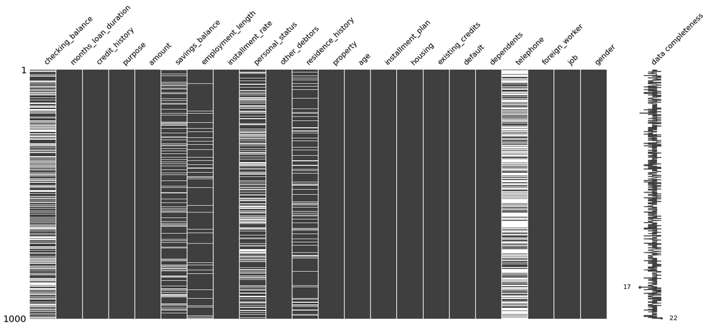

```python
#msno.matrix(df)
msno.matrix(df,labels=True)
plt.show()
```

The charts displays columns with missing records as listed below

- checking_balance
- savings_balance
- employment_length
- personal_status
- residence_history
- telephone- create flag, has telephone/No telephone

```python
missing_percentage = (df.isna().sum() / len(df)) * 100
print(missing_percentage)
```

```
checking_balance       39.400
months_loan_duration    0.000
credit_history          0.000
purpose                 0.000
amount                  0.000
savings_balance        18.300
employment_length       6.200
installment_rate        0.000
personal_status        31.000
other_debtors           0.000
residence_history      13.000
property                0.000
age                     0.000
installment_plan        0.000
housing                 0.000
existing_credits        0.000
default                 0.000
dependents              0.000
telephone              59.600
foreign_worker          0.000
job                     0.000
gender                  0.000
dtype: float64
```

```python
df.columns
```

```
Index(['checking_balance', 'months_loan_duration', 'credit_history', 'purpose',
       'amount', 'savings_balance', 'employment_length', 'installment_rate',
       'personal_status', 'other_debtors', 'residence_history', 'property',
       'age', 'installment_plan', 'housing', 'existing_credits', 'default',
       'dependents', 'telephone', 'foreign_worker', 'job', 'gender'],
      dtype='object')
```

```python
# Count duplicated rows
count_duplicates = df.duplicated().sum()
# Print the count of duplicated rows
print("Count of duplicated rows:", count_duplicates)
```

```
Count of duplicated rows: 0
```

- No duplicated records from the dataset

## Data cleaning and preprocessing

- I Filled the missing values for the categorical columns with arbitrary values(**Missing**) as to gain insights into the characteristics of good and bad credit and to observe how the presence of missing values impacts those characteristics

```python
# Select categorical columns with missing values
columns_with_missing = ['employment_length', 'personal_status', 'residence_history']

# Fill missing values in selected columns with 'missing'
df[columns_with_missing] = df[columns_with_missing].fillna('missing')
```

```python
# Get categorical columns as a list
categorical_columns = df.select_dtypes(include=['object']).columns.tolist()
print("Categorical columns:")
print(categorical_columns)

# Get numerical columns as a list
numerical_columns = df.select_dtypes(include=['int64', 'float64']).columns.tolist()
print("\nNumerical columns:")
print(numerical_columns)
```

```
Categorical columns:
['credit_history', 'purpose', 'employment_length', 'personal_status', 'other_debtors', 'residence_history', 'property', 'installment_plan', 'housing', 'foreign_worker', 'job', 'gender']

Numerical columns:
['checking_balance', 'months_loan_duration', 'amount', 'savings_balance', 'installment_rate', 'age', 'existing_credits', 'default', 'dependents', 'telephone']
```

```python
# the document shared states 1 is a good loan, 2 is a defaulting one.While the data says 0 and 1
df.default.value_counts()
```

```
0    700
1    300
Name: default, dtype: int64
```

```python
def risk_flag(dataframe):
    doc = { 0: 'Good',
            1: 'Bad'}

    dataframe['risk_flag'] = dataframe['default'].replace(doc)
    return dataframe
```

```python
df=risk_flag(df)
```

```python
data=df.copy()
```

```python
data[['checking_balance','months_loan_duration','amount','savings_balance','installment_rate','age','dependents']].describe()
```

|  | checking_balance | months_loan_duration | amount | savings_balance | installment_rate | age | dependents |
| --- | --- | --- | --- | --- | --- | --- | --- |
| count | 606.000 | 1000.000 | 1000.000 | 817.000 | 1000.000 | 1000.000 | 1000.000 |
| mean | 97.246 | 20.903 | 3271.258 | 781.570 | 2.973 | 35.546 | 1.155 |
| std | 206.924 | 12.059 | 2822.737 | 3016.984 | 1.119 | 11.375 | 0.362 |
| min | -50.000 | 4.000 | 250.000 | 0.000 | 1.000 | 19.000 | 1.000 |
| 25% | -23.000 | 12.000 | 1365.500 | 31.000 | 2.000 | 27.000 | 1.000 |
| 50% | 24.000 | 18.000 | 2319.500 | 64.000 | 3.000 | 33.000 | 1.000 |
| 75% | 131.750 | 24.000 | 3972.250 | 128.000 | 4.000 | 42.000 | 1.000 |
| max | 999.000 | 72.000 | 18424.000 | 19972.000 | 4.000 | 75.000 | 2.000 |

### Basic descriptive stats

- The "checking_balance" has a wide range of values, with some negative values and a maximum of 999, indicating possible outliers.
- The "months_loan_duration" ranges from 4 to 72 months, with a median of 18 months.
- The "amount" of loans varies significantly, ranging from 250 to 18424, with a median of 2319.5.
- The "savings_balance" column has missing values (count: 817) and shows variability from 0 to 19972.
- The "installment_rate" is categorical, with four distinct values (1, 2, 3, 4).
- The "age" of customers ranges from 19 to 75, with a mean of approximately 35.5 years.
- The "dependents" column has mostly one value (1), with a small number of records having two dependents (max: 2).

### Desciptive stats on the Categorical Columns

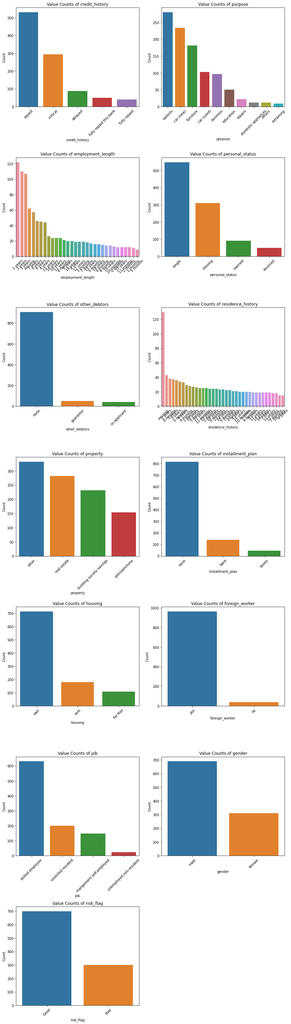

```python
# Create a list of columns to visualize
selected_columns = ['credit_history', 'purpose', 'employment_length', 'personal_status', 'other_debtors', 'residence_history', 'property', 'installment_plan', 'housing', 'foreign_worker', 'job', 'gender','risk_flag']

# Calculate the number of rows and columns needed for subplots
num_plots = len(selected_columns)
num_cols = 2
num_rows = math.ceil(num_plots / num_cols)

# Create subplots for the selected columns
fig, axs = plt.subplots(num_rows, num_cols, figsize=(12, 6 * num_rows))

# Iterate over the selected columns and visualize them
for i, column in enumerate(selected_columns):
    row = i // num_cols
    col = i % num_cols

    # Count the occurrences of each category in the column
    category_counts = data[column].value_counts()

    # Create a bar plot using seaborn
    sns.barplot(x=category_counts.index, y=category_counts.values, ax=axs[row, col])

    # Set labels and title
    axs[row, col].set_xlabel(column)
    axs[row, col].set_ylabel('Count')
    axs[row, col].set_title(f'Value Counts of {column}')

    axs[row, col].tick_params(axis='x', rotation=45)  # Rotate x-axis labels if necessary

# Remove any unused subplots
if num_plots < num_rows * num_cols:
    for i in range(num_plots, num_rows * num_cols):
        fig.delaxes(axs.flatten()[i])

plt.tight_layout()  # Adjust spacing between subplots
plt.show()  # Display the plots
```

Quick Observations

- employment length is computed as a cateogrical column in months/years
- similarly the residence history have categories in months/years

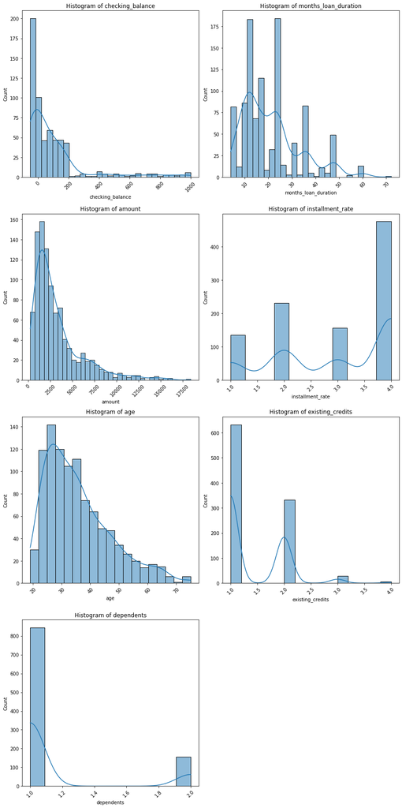

```python
# Create a list of numerical columns to visualize
selected_columns = ['checking_balance','months_loan_duration', 'amount', 'installment_rate', 'age', 'existing_credits', 'dependents']

# Calculate the number of rows and columns needed for subplots
num_plots = len(selected_columns)
num_cols = 2
num_rows = math.ceil(num_plots / num_cols)

# Create subplots for the selected columns
fig, axs = plt.subplots(num_rows, num_cols, figsize=(12, 6 * num_rows))

# Iterate over the selected columns and visualize them
for i, column in enumerate(selected_columns):
    row = i // num_cols
    col = i % num_cols

    # Create a histogram using seaborn
    sns.histplot(df[column], ax=axs[row, col], kde=True)

    # Set labels and title
    axs[row, col].set_xlabel(column)
    axs[row, col].set_ylabel('Count')
    axs[row, col].set_title(f'Histogram of {column}')

    axs[row, col].tick_params(axis='x', rotation=45)  # Rotate x-axis labels if necessary

# Remove any unused subplots
if num_plots < num_rows * num_cols:
    for i in range(num_plots, num_rows * num_cols):
        fig.delaxes(axs.flatten()[i])

plt.tight_layout()  # Adjust spacing between subplots
plt.show()  # Display the plots
```

Observations

- We have observed instances where customers possess a negative checking balance.
- The histogram of the age distribution reveals a central tendency around the age range of 30 to 40, suggesting an average age within this range.i.e most of the customers are middle aged

## Feature Engineering

```python
data[['checking_balance','savings_balance','employment_length','residence_history','telephone']].head(10)
```

|  | checking_balance | savings_balance | employment_length | residence_history | telephone |
| --- | --- | --- | --- | --- | --- |
| 0 | -43.000 | NaN | 13 years | 6 years | 2349339647.000 |
| 1 | 75.000 | 89.000 | 2 years | 5 months | NaN |
| 2 | NaN | 24.000 | 5 years | 4 years | NaN |
| 3 | -32.000 | 9.000 | 5 years | 13 years | NaN |
| 4 | -23.000 | 43.000 | 3 years | 13 years | NaN |
| 5 | NaN | NaN | 2 years | 8 years | 2345787903.000 |
| 6 | NaN | 761.000 | 11 years | 12 years | NaN |
| 7 | 169.000 | 57.000 | 2 years | 3 months | 2349961683.000 |
| 8 | NaN | 18426.000 | 4 years | 24 years | NaN |
| 9 | 13.000 | 52.000 | missing | 10 months | NaN |

```python
data.savings_balance.min()
```

```
0.0
```

**Observations**

- In the **'checking_balance'** column, we encountered cases where customers had negative balances. Consequently, we engineered a new feature called 'checking balance flag' i.e for customers with positive bal are named(positive balance), negative values as negative balance, and customers with no balance as (no balance)
- For the **'savings_balance'** column, we introduced a flag to indicate whether a customer has a savings balance or not.
- Regarding the **'employment_length'** column, which originally captured durations in months or years, we created a new column to standardize employment length by converting it to months.
- Similar to 'employment_length', we derived a new column for **'residence_history'** to handle the duration of residence in months.
- For the **'Telephone'** column, we generated a flag to distinguish customers with phone numbers from those without (missing values).

```python
def create_balance_flag(df, column_name):
    """This function takes a DataFrame (df) as
    input and creates a new column called 'checking_balance_flag'.
    It then sets the flag based on the specified conditions"""
    # Create a new column for the flag with default value 'positive_balance'
    flag_column = f'{column_name}_flag'
    df[flag_column] = f'pos_{column_name}'

    # Update the flag based on conditions
    df.loc[df[column_name] < 0, flag_column] = f'neg_{column_name}'
    df.loc[df[column_name].isnull(), flag_column] = f'no_{column_name}'

    return df
data=create_balance_flag(data,'checking_balance')
```

```python
def create_savings_balance_flag(df):
    # Create a new column for the flag with default value 'no_saving_bal'
    df['savings_balance_flag'] = 'no_saving_bal'

    # Update the flag to 'has_saving_bal' for non-null savings balance values
    df.loc[df['savings_balance'].notnull(), 'savings_balance_flag'] = 'has_saving_bal'

    return df
data=create_savings_balance_flag(data)
```

```python
data.head(1)
```

|  | checking_balance | months_loan_duration | credit_history | purpose | amount | savings_balance | employment_length | installment_rate | personal_status | other_debtors | residence_history | property | age | installment_plan | housing | existing_credits | default | dependents | telephone | foreign_worker | job | gender | risk_flag | checking_balance_flag | savings_balance_flag |
| --- | --- | --- | --- | --- | --- | --- | --- | --- | --- | --- | --- | --- | --- | --- | --- | --- | --- | --- | --- | --- | --- | --- | --- | --- | --- |
| 0 | -43.000 | 6 | critical | radio/tv | 1169 | NaN | 13 years | 4 | single | none | 6 years | real estate | 67 | none | own | 2 | 0 | 1 | 2349339647.000 | yes | skilled employee | male | Good | neg_checking_balance | no_saving_bal |

```python
def convert_to_months(df, column_name):
    new_column_name = f'{column_name}_month'

    # Extract the numeric portion of the strings in the column
    df[new_column_name] = df[column_name].str.extract('(\d+)').astype(float)

    # Multiply the values by 12 if the strings contain 'year' to convert to months
    df.loc[df[column_name].str.contains('year', case=False), new_column_name] *= 12

    return df
data=convert_to_months(data,'employment_length')
data=convert_to_months(data,'residence_history')
```

```python
def create_telephone_flag(df):
    # Create a new column for the flag with default value 'no_telephone'
    df['telephone_flag'] = 'no_telephone'

    # Update the flag to 'telephone' for non-null telephone values
    df.loc[df['telephone'].notnull(), 'telephone_flag'] = 'has_telephone'

    return df
data=create_telephone_flag(data)
```

```python
data.head(1)
```

|  | checking_balance | months_loan_duration | credit_history | purpose | amount | savings_balance | employment_length | installment_rate | personal_status | other_debtors | residence_history | property | age | installment_plan | housing | existing_credits | default | dependents | telephone | foreign_worker | job | gender | risk_flag | checking_balance_flag | savings_balance_flag | employment_length_month | residence_history_month | telephone_flag |
| --- | --- | --- | --- | --- | --- | --- | --- | --- | --- | --- | --- | --- | --- | --- | --- | --- | --- | --- | --- | --- | --- | --- | --- | --- | --- | --- | --- | --- |
| 0 | -43.000 | 6 | critical | radio/tv | 1169 | NaN | 13 years | 4 | single | none | 6 years | real estate | 67 | none | own | 2 | 0 | 1 | 2349339647.000 | yes | skilled employee | male | Good | neg_checking_balance | no_saving_bal | 156.000 | 72.000 | has_telephone |

```python
data.columns
```

```
Index(['checking_balance', 'months_loan_duration', 'credit_history', 'purpose',
       'amount', 'savings_balance', 'employment_length', 'installment_rate',
       'personal_status', 'other_debtors', 'residence_history', 'property',
       'age', 'installment_plan', 'housing', 'existing_credits', 'default',
       'dependents', 'telephone', 'foreign_worker', 'job', 'gender',
       'risk_flag', 'checking_balance_flag', 'savings_balance_flag',
       'employment_length_month', 'residence_history_month', 'telephone_flag'],
      dtype='object')
```

# EDA: Risk Evaluation using the independent variables

Goal:- Check the charasteristic of risk flag with respect to the independent varaibles

Features can be grouped into

- **credit features** -> [months_loan_duration, credit_history, purpose, amount, installment_rate, personal_status, other_debtors,installment_plan, housing, existing_credits, property, default, risk_flag, employment_length_month, residence_history_month, telephone_flag]
- **demographic features** -> [dependents, telephone, foreign_worker, job, gender]
- **behavioural features** -> [checking_balance,savings_balance,residence_history_month, employment_length,checking_balance_flag, savings_balance_flag]

## Loan Amount

- Larger loan amount tends to pose a higher risk of defaulters

```python
#Used for the binning process
data['Amount_bucket'] = pd.qcut(data['amount'], q=5, precision=0)
```

```python
# Use function and insert dataframe'data'
display_crosstab_side_by_side(data, 'Amount_bucket', 'risk_flag')
```

| risk_flag Amount_bucket | Bad | Good |
| --- | --- | --- |
| (249.0, 1262.0] | 61 | 140 |
| (1262.0, 1907.0] | 48 | 151 |
| (1907.0, 2852.0] | 54 | 146 |
| (2852.0, 4720.0] | 52 | 148 |
| (4720.0, 18424.0] | 85 | 115 |

| risk_flag Amount_bucket | Bad | Good |
| --- | --- | --- |
| (249.0, 1262.0] | 6 | 14 |
| (1262.0, 1907.0] | 5 | 15 |
| (1907.0, 2852.0] | 5 | 15 |
| (2852.0, 4720.0] | 5 | 15 |
| (4720.0, 18424.0] | 8 | 12 |

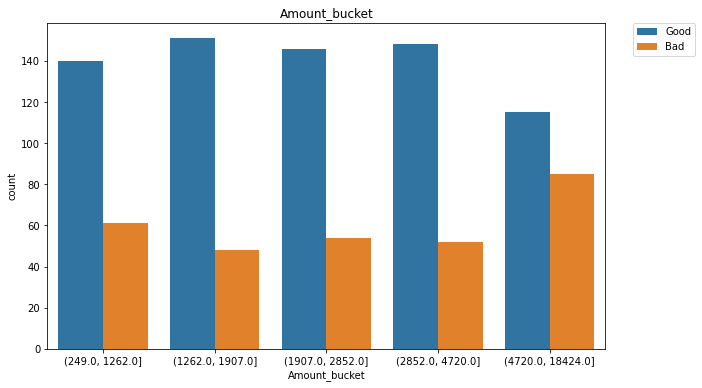

```python
plt.figure(figsize=(10, 6))
ax = sns.countplot(x="Amount_bucket", hue="risk_flag", data=data)
plt.legend(bbox_to_anchor=(1.05, 1), loc=2, borderaxespad=0.)
plt.title("Amount_bucket")
plt.show()
```

## Loan_duration

Longer loan duration tend to pose potentail risk, though we can as well deduce that customers within average duration posing potential risk

```python
#Used for the binning process
data['months_loan_duration_bucket'] = pd.qcut(data['months_loan_duration'], q=5, precision=0)
```

```python
# Use function and insert dataframe'data'
display_crosstab_side_by_side(data, 'months_loan_duration_bucket', 'risk_flag')
```

| risk_flag months_loan_duration_bucket | Bad | Good |
| --- | --- | --- |
| (3.0, 12.0] | 76 | 283 |
| (12.0, 15.0] | 13 | 59 |
| (15.0, 24.0] | 109 | 230 |
| (24.0, 30.0] | 19 | 38 |
| (30.0, 72.0] | 83 | 90 |

| risk_flag months_loan_duration_bucket | Bad | Good |
| --- | --- | --- |
| (3.0, 12.0] | 8 | 28 |
| (12.0, 15.0] | 1 | 6 |
| (15.0, 24.0] | 11 | 23 |
| (24.0, 30.0] | 2 | 4 |
| (30.0, 72.0] | 8 | 9 |

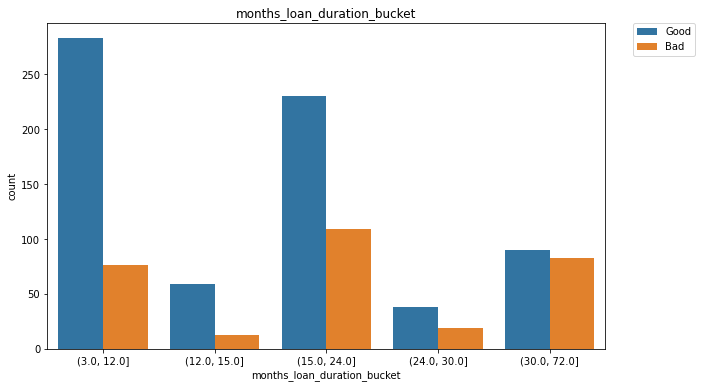

```python
plt.figure(figsize=(10, 6))
ax = sns.countplot(x="months_loan_duration_bucket", hue="risk_flag", data=data)
plt.legend(bbox_to_anchor=(1.05, 1), loc=2, borderaxespad=0.)
plt.title("months_loan_duration_bucket")
plt.show()
```

## Credit History

```python
# Use function and insert dataframe'data'
display_crosstab_side_by_side(data, 'credit_history', 'risk_flag')
```

| risk_flag credit_history | Bad | Good |
| --- | --- | --- |
| critical | 50 | 243 |
| delayed | 28 | 60 |
| fully repaid | 25 | 15 |
| fully repaid this bank | 28 | 21 |
| repaid | 169 | 361 |

| risk_flag credit_history | Bad | Good |
| --- | --- | --- |
| critical | 5 | 24 |
| delayed | 3 | 6 |
| fully repaid | 2 | 2 |
| fully repaid this bank | 3 | 2 |
| repaid | 17 | 36 |

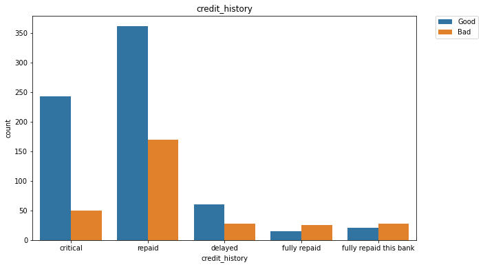

```python
plt.figure(figsize=(10, 6))
ax = sns.countplot(x="credit_history", hue="risk_flag", data=data)
plt.legend(bbox_to_anchor=(1.05, 1), loc=2, borderaxespad=0.)
plt.title("credit_history")
plt.show()
```

## PURPOSE

- I hypothesize that the **purpose** stated by the customers for their loan applications reflects their intended use of the funds.

Customers whos intent is to use there loan to purchase a car tend to show significant risk Though we can see that for most customers, the intended use of their loan is to get RADIO/TV,CAR,FURNITURE

```python
# Use function and insert dataframe'data'
display_crosstab_side_by_side(data, 'risk_flag', 'purpose')
```

| purpose risk_flag | business | car (new) | car (used) | domestic appliances | education | furniture | others | radio/tv | repairs | retraining |
| --- | --- | --- | --- | --- | --- | --- | --- | --- | --- | --- |
| Bad | 34 | 89 | 17 | 4 | 22 | 58 | 5 | 62 | 8 | 1 |
| Good | 63 | 145 | 86 | 8 | 28 | 123 | 7 | 218 | 14 | 8 |

| purpose risk_flag | business | car (new) | car (used) | domestic appliances | education | furniture | others | radio/tv | repairs | retraining |
| --- | --- | --- | --- | --- | --- | --- | --- | --- | --- | --- |
| Bad | 3 | 9 | 2 | 0 | 2 | 6 | 0 | 6 | 1 | 0 |
| Good | 6 | 14 | 9 | 1 | 3 | 12 | 1 | 22 | 1 | 1 |

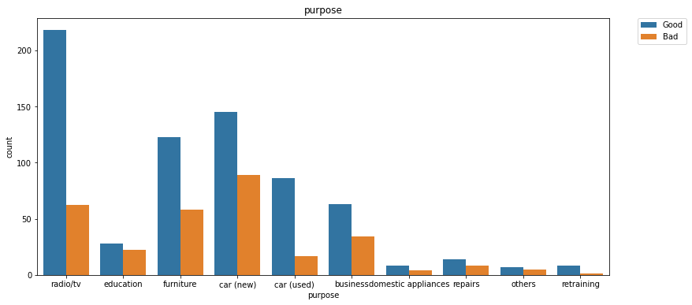

```python
plt.figure(figsize=(13, 6))
ax = sns.countplot(x="purpose", hue="risk_flag", data=data)
plt.legend(bbox_to_anchor=(1.05, 1), loc=2, borderaxespad=0.)
plt.title("purpose")
plt.show()
```

# PERSONAL STATUS

Findings below doesnt really show any factors that distinguish good and bad customers Though we can see that for most customers, there personal status is **single**, while some of have there status as missing

```python
# Use function and insert dataframe'data'
display_crosstab_side_by_side(data, 'personal_status', 'risk_flag')
```

| risk_flag personal_status | Bad | Good |
| --- | --- | --- |
| divorced | 20 | 30 |
| married | 25 | 67 |
| missing | 109 | 201 |
| single | 146 | 402 |

| risk_flag personal_status | Bad | Good |
| --- | --- | --- |
| divorced | 2 | 3 |
| married | 2 | 7 |
| missing | 11 | 20 |
| single | 15 | 40 |

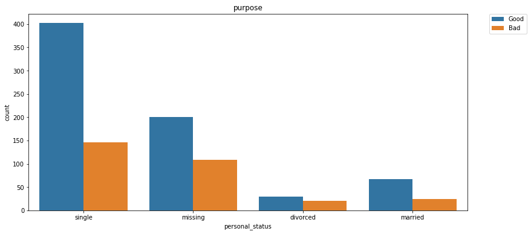

```python
plt.figure(figsize=(13, 6))
ax = sns.countplot(x="personal_status", hue="risk_flag", data=data)
plt.legend(bbox_to_anchor=(1.05, 1), loc=2, borderaxespad=0.)
plt.title("purpose")
plt.show()
```

# other debtors

- I hypothezize here that "other_debtors" refers to individuals or entities who are co-signers or guarantors on a loan taken by the primary borrower.

Findings below doesnt really show any factors that distinguish good and bad customers

```python
# Use function and insert dataframe'data'
display_crosstab_side_by_side(data, 'other_debtors', 'risk_flag')
```

| risk_flag other_debtors | Bad | Good |
| --- | --- | --- |
| co-applicant | 18 | 23 |
| guarantor | 10 | 42 |
| none | 272 | 635 |

| risk_flag other_debtors | Bad | Good |
| --- | --- | --- |
| co-applicant | 2 | 2 |
| guarantor | 1 | 4 |
| none | 27 | 64 |

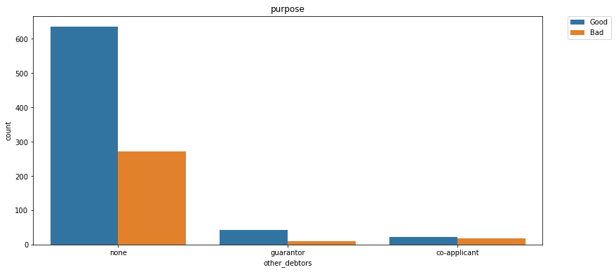

```python
plt.figure(figsize=(13, 6))
ax = sns.countplot(x="other_debtors", hue="risk_flag", data=data)
plt.legend(bbox_to_anchor=(1.05, 1), loc=2, borderaxespad=0.)
plt.title("purpose")
plt.show()
```

# PROPERTY

- Type of collateral that a borrower provides to secure a loan.

```python
# Use function and insert dataframe'data'
display_crosstab_side_by_side(data, 'property', 'risk_flag')
```

| risk_flag property | Bad | Good |
| --- | --- | --- |
| building society savings | 71 | 161 |
| other | 102 | 230 |
| real estate | 60 | 222 |
| unknown/none | 67 | 87 |

| risk_flag property | Bad | Good |
| --- | --- | --- |
| building society savings | 7 | 16 |
| other | 10 | 23 |
| real estate | 6 | 22 |
| unknown/none | 7 | 9 |

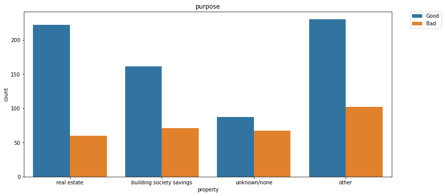

```python
plt.figure(figsize=(13, 6))
ax = sns.countplot(x="property", hue="risk_flag", data=data)
plt.legend(bbox_to_anchor=(1.05, 1), loc=2, borderaxespad=0.)
plt.title("purpose")
plt.show()
```

## Installment Plan

- "installment plan" here i assumed to be specific method of repayment for a loan.

Findings below doesnt really show any factors that distinguish good and bad customers

```python
# Use function and insert dataframe'data'
display_crosstab_side_by_side(data, 'installment_plan', 'risk_flag')
```

| risk_flag installment_plan | Bad | Good |
| --- | --- | --- |
| bank | 57 | 82 |
| none | 224 | 590 |
| stores | 19 | 28 |

| risk_flag installment_plan | Bad | Good |
| --- | --- | --- |
| bank | 6 | 8 |
| none | 22 | 59 |
| stores | 2 | 3 |

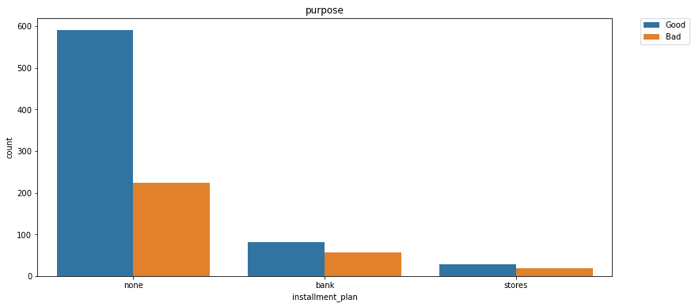

```python
plt.figure(figsize=(13, 6))
ax = sns.countplot(x="installment_plan", hue="risk_flag", data=data)
plt.legend(bbox_to_anchor=(1.05, 1), loc=2, borderaxespad=0.)
plt.title("purpose")
plt.show()
```

## Housing

- Most of the customers are home owners, while we can see a slight significant proportion of bad customers are tenanats

```python
# Use function and insert dataframe'data'
display_crosstab_side_by_side(data, 'housing', 'risk_flag')
```

| risk_flag housing | Bad | Good |
| --- | --- | --- |
| for free | 44 | 64 |
| own | 186 | 527 |
| rent | 70 | 109 |

| risk_flag housing | Bad | Good |
| --- | --- | --- |
| for free | 4 | 6 |
| own | 19 | 53 |
| rent | 7 | 11 |

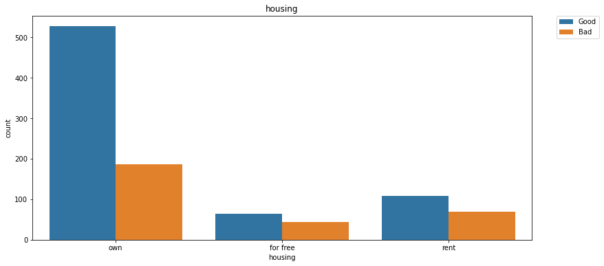

```python
plt.figure(figsize=(13, 6))
ax = sns.countplot(x="housing", hue="risk_flag", data=data)
plt.legend(bbox_to_anchor=(1.05, 1), loc=2, borderaxespad=0.)
plt.title("housing")
plt.show()
```

## Existing Credits

- Most of the customer have a existing credit ranging from 1 and 2

```python
# Use function and insert dataframe'data'
display_crosstab_side_by_side(data, 'existing_credits', 'risk_flag')
```

| risk_flag existing_credits | Bad | Good |
| --- | --- | --- |
| 1 | 200 | 433 |
| 2 | 92 | 241 |
| 3 | 6 | 22 |
| 4 | 2 | 4 |

| risk_flag existing_credits | Bad | Good |
| --- | --- | --- |
| 1 | 20 | 43 |
| 2 | 9 | 24 |
| 3 | 1 | 2 |
| 4 | 0 | 0 |

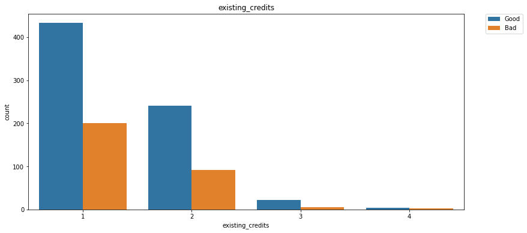

```python
plt.figure(figsize=(13, 6))
ax = sns.countplot(x="existing_credits", hue="risk_flag", data=data)
plt.legend(bbox_to_anchor=(1.05, 1), loc=2, borderaxespad=0.)
plt.title("existing_credits")
plt.show()
```

## Age

- Customers between the age of 19 to 26 years appears to be potential risk, while the good customers appears to be characterized as older age

```python
data.age.max()
```

```
75
```

```python
#Used for the binning process
data['age_bucket'] = pd.qcut(data['age'], q=5, precision=0)
```

```python
# Use function and insert dataframe'data'
display_crosstab_side_by_side(data, 'age_bucket', 'risk_flag')
```

| risk_flag age_bucket | Bad | Good |
| --- | --- | --- |
| (18.0, 26.0] | 94 | 146 |
| (26.0, 30.0] | 54 | 117 |
| (30.0, 36.0] | 56 | 160 |
| (36.0, 45.0] | 49 | 138 |
| (45.0, 75.0] | 47 | 139 |

| risk_flag age_bucket | Bad | Good |
| --- | --- | --- |
| (18.0, 26.0] | 9 | 15 |
| (26.0, 30.0] | 5 | 12 |
| (30.0, 36.0] | 6 | 16 |
| (36.0, 45.0] | 5 | 14 |
| (45.0, 75.0] | 5 | 14 |

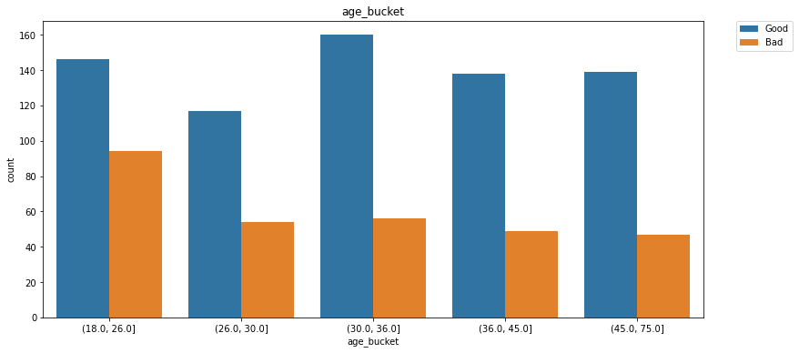

```python
plt.figure(figsize=(13, 6))
ax = sns.countplot(x="age_bucket", hue="risk_flag", data=data)
plt.legend(bbox_to_anchor=(1.05, 1), loc=2, borderaxespad=0.)
plt.title("age_bucket")
plt.show()
```

## Dependents

Findings below doesnt really show any factors that distinguish good and bad customers, but we can see a high proprtion of customers have 1 dependents

```python
# Use function and insert dataframe'data'
display_crosstab_side_by_side(data, 'dependents', 'risk_flag')
```

| risk_flag dependents | Bad | Good |
| --- | --- | --- |
| 1 | 254 | 591 |
| 2 | 46 | 109 |

| risk_flag dependents | Bad | Good |
| --- | --- | --- |
| 1 | 25 | 59 |
| 2 | 5 | 11 |

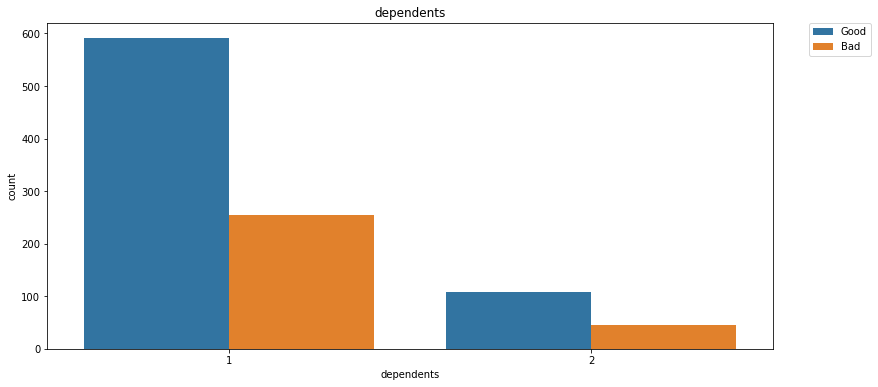

```python
plt.figure(figsize=(13, 6))
ax = sns.countplot(x="dependents", hue="risk_flag", data=data)
plt.legend(bbox_to_anchor=(1.05, 1), loc=2, borderaxespad=0.)
plt.title("dependents")
plt.show()
```

## Foreign_Worker

A significaant portion of the customers are Foreign workers

```python
# Use function and insert dataframe'data'
display_crosstab_side_by_side(data, 'foreign_worker', 'risk_flag')
```

| risk_flag foreign_worker | Bad | Good |
| --- | --- | --- |
| no | 4 | 33 |
| yes | 296 | 667 |

| risk_flag foreign_worker | Bad | Good |
| --- | --- | --- |
| no | 0 | 3 |
| yes | 30 | 67 |

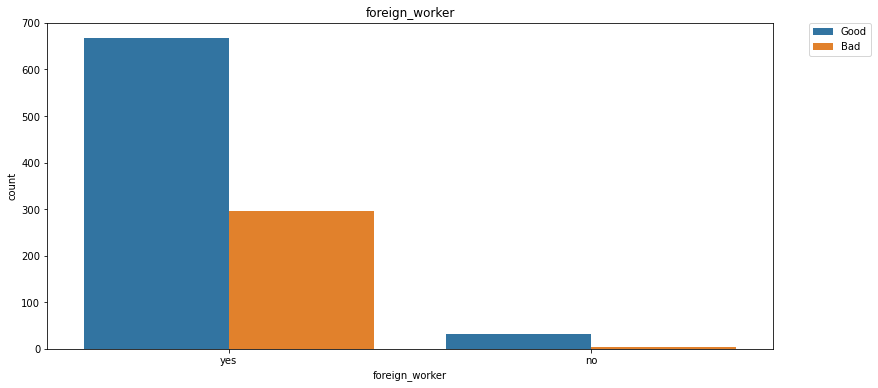

```python
plt.figure(figsize=(13, 6))
ax = sns.countplot(x="foreign_worker", hue="risk_flag", data=data)
plt.legend(bbox_to_anchor=(1.05, 1), loc=2, borderaxespad=0.)
plt.title("foreign_worker")
plt.show()
```

# checking_balance

- we can see a significatnt portion of the bad customers have negative balance

```python
#Used for the binning process
data['checking_balance_bucket'] = pd.qcut(data['checking_balance'], q=5, precision=0)
```

```python
# Use function and insert dataframe'data'
display_crosstab_side_by_side(data, 'checking_balance_bucket', 'risk_flag')
```

| risk_flag checking_balance_bucket | Bad | Good |
| --- | --- | --- |
| (-51.0, -29.0] | 63 | 62 |
| (-29.0, -7.0] | 52 | 67 |
| (-7.0, 71.0] | 57 | 65 |
| (71.0, 155.0] | 48 | 73 |
| (155.0, 999.0] | 34 | 85 |

| risk_flag checking_balance_bucket | Bad | Good |
| --- | --- | --- |
| (-51.0, -29.0] | 10 | 10 |
| (-29.0, -7.0] | 9 | 11 |
| (-7.0, 71.0] | 9 | 11 |
| (71.0, 155.0] | 8 | 12 |
| (155.0, 999.0] | 6 | 14 |

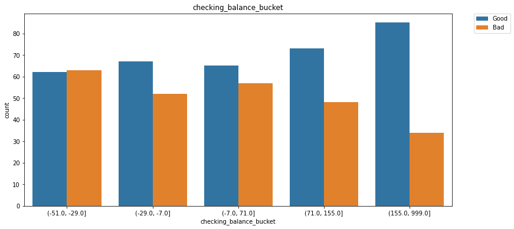

```python
plt.figure(figsize=(13, 6))
ax = sns.countplot(x="checking_balance_bucket", hue="risk_flag", data=data)
plt.legend(bbox_to_anchor=(1.05, 1), loc=2, borderaxespad=0.)
plt.title("checking_balance_bucket")
plt.show()
```

## checking_balance_flag

- This is a derived feature as explained ealier , we can see a significatnt portion of the **bad** customers have negative balance

```python
# Use function and insert dataframe'data'
display_crosstab_side_by_side(data, 'checking_balance_flag', 'risk_flag')
```

| risk_flag checking_balance_flag | Bad | Good |
| --- | --- | --- |
| neg_checking_balance | 135 | 139 |
| no_checking_balance | 46 | 348 |
| pos_checking_balance | 119 | 213 |

| risk_flag checking_balance_flag | Bad | Good |
| --- | --- | --- |
| neg_checking_balance | 14 | 14 |
| no_checking_balance | 5 | 35 |
| pos_checking_balance | 12 | 21 |

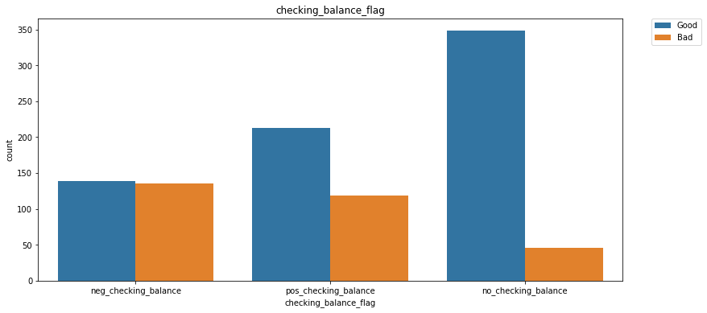

```python
plt.figure(figsize=(13, 6))
ax = sns.countplot(x="checking_balance_flag", hue="risk_flag", data=data)
plt.legend(bbox_to_anchor=(1.05, 1), loc=2, borderaxespad=0.)
plt.title("checking_balance_flag")
plt.show()
```

## savings_balance

we can see a significatnt portion of the bad(Default) customers have low savings balance, compared to the good customers. This feature properly distinguish the charcteristics of defaulters and non defualters

```python
#Used for the binning process
data['savings_balance_bucket'] = pd.qcut(data['savings_balance'], q=5, precision=0)
```

```python
# Use function and insert dataframe'data'
display_crosstab_side_by_side(data, 'savings_balance_bucket', 'risk_flag')
```

| risk_flag savings_balance_bucket | Bad | Good |
| --- | --- | --- |
| (-1.0, 25.0] | 63 | 104 |
| (25.0, 51.0] | 64 | 101 |
| (51.0, 80.0] | 57 | 102 |
| (80.0, 305.0] | 43 | 119 |
| (305.0, 19972.0] | 41 | 123 |

| risk_flag savings_balance_bucket | Bad | Good |
| --- | --- | --- |
| (-1.0, 25.0] | 8 | 13 |
| (25.0, 51.0] | 8 | 12 |
| (51.0, 80.0] | 7 | 12 |
| (80.0, 305.0] | 5 | 15 |
| (305.0, 19972.0] | 5 | 15 |

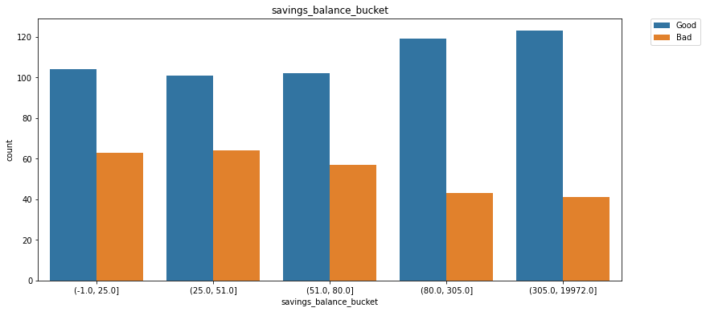

```python
plt.figure(figsize=(13, 6))
ax = sns.countplot(x="savings_balance_bucket", hue="risk_flag", data=data)
plt.legend(bbox_to_anchor=(1.05, 1), loc=2, borderaxespad=0.)
plt.title("savings_balance_bucket")
plt.show()
```

## savings_balance_flag

```python
# Use function and insert dataframe'data'
display_crosstab_side_by_side(data, 'savings_balance_flag', 'risk_flag')
```

| risk_flag savings_balance_flag | Bad | Good |
| --- | --- | --- |
| has_saving_bal | 268 | 549 |
| no_saving_bal | 32 | 151 |

| risk_flag savings_balance_flag | Bad | Good |
| --- | --- | --- |
| has_saving_bal | 27 | 55 |
| no_saving_bal | 3 | 15 |

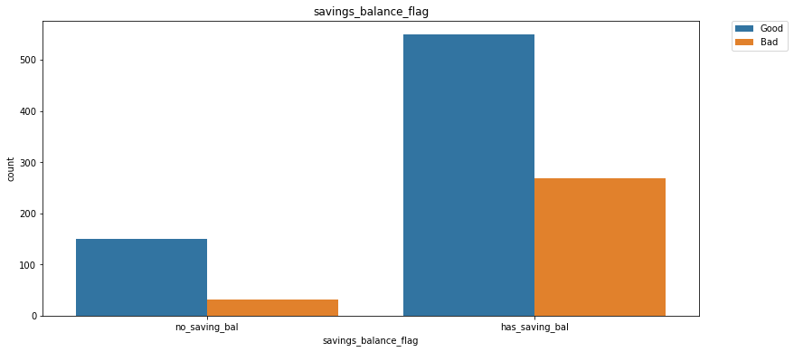

```python
plt.figure(figsize=(13, 6))
ax = sns.countplot(x="savings_balance_flag", hue="risk_flag", data=data)
plt.legend(bbox_to_anchor=(1.05, 1), loc=2, borderaxespad=0.)
plt.title("savings_balance_flag")
plt.show()
```

## telephone_flag

Customer with no telephone tend to pose potentail risk(defaulters).

```python
# Use function and insert dataframe'data'
display_crosstab_side_by_side(data, 'telephone_flag', 'risk_flag')
```

| risk_flag telephone_flag | Bad | Good |
| --- | --- | --- |
| has_telephone | 113 | 291 |
| no_telephone | 187 | 409 |

| risk_flag telephone_flag | Bad | Good |
| --- | --- | --- |
| has_telephone | 11 | 29 |
| no_telephone | 19 | 41 |

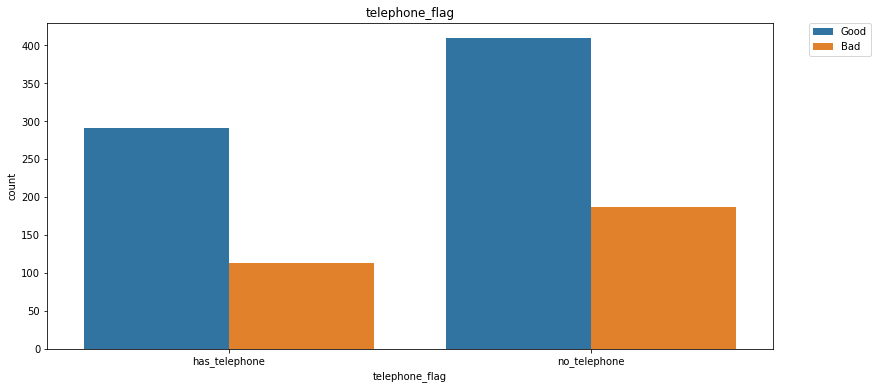

```python
plt.figure(figsize=(13, 6))
ax = sns.countplot(x="telephone_flag", hue="risk_flag", data=data)
plt.legend(bbox_to_anchor=(1.05, 1), loc=2, borderaxespad=0.)
plt.title("telephone_flag")
plt.show()
```

## Residence_history_month

A notable observation is that a significant portion of bad customers have a relatively short residence history in months. From this, we can infer that individuals who have recently started working or have limited residential stability may be more prone to becoming potential defaulters.

```python
#Used for the binning process
data['Residence_history_month_bucket'] = pd.qcut(data['residence_history_month'], q=5, precision=0)
```

```python
# Use function and insert dataframe'data'
display_crosstab_side_by_side(data, 'Residence_history_month_bucket', 'risk_flag')
```

| risk_flag Residence_history_month_bucket | Bad | Good |
| --- | --- | --- |
| (-1.0, 6.0] | 61 | 117 |
| (6.0, 24.0] | 58 | 152 |
| (24.0, 96.0] | 46 | 98 |
| (96.0, 192.0] | 47 | 123 |
| (192.0, 288.0] | 52 | 116 |

| risk_flag Residence_history_month_bucket | Bad | Good |
| --- | --- | --- |
| (-1.0, 6.0] | 7 | 13 |
| (6.0, 24.0] | 7 | 17 |
| (24.0, 96.0] | 5 | 11 |
| (96.0, 192.0] | 5 | 14 |
| (192.0, 288.0] | 6 | 13 |

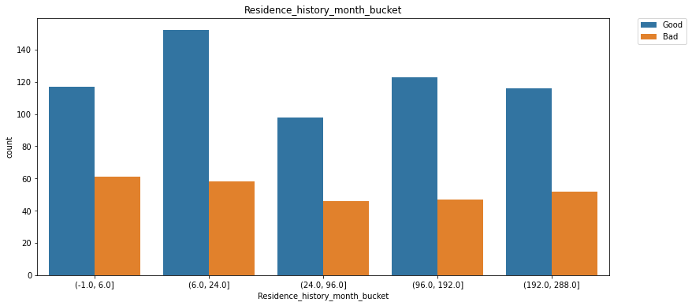

```python
plt.figure(figsize=(13, 6))
ax = sns.countplot(x="Residence_history_month_bucket", hue="risk_flag", data=data)
plt.legend(bbox_to_anchor=(1.05, 1), loc=2, borderaxespad=0.)
plt.title("Residence_history_month_bucket")
plt.show()
```

## Employment_length_months

We can see a signifiatnt proportion of bad customer has short emploment length. We can deduce that low employment length customers will be potential defualters

```python
#Used for the binning process
data['employment_length_bucket'] = pd.qcut(data['employment_length_month'], q=5, precision=0)
```

```python
# Use function and insert dataframe'data'
display_crosstab_side_by_side(data, 'employment_length_bucket', 'risk_flag')
```

| risk_flag employment_length_bucket | Bad | Good |
| --- | --- | --- |
| (-1.0, 12.0] | 107 | 187 |
| (12.0, 24.0] | 35 | 75 |
| (24.0, 60.0] | 53 | 144 |
| (60.0, 120.0] | 41 | 124 |
| (120.0, 228.0] | 41 | 131 |

| risk_flag employment_length_bucket | Bad | Good |
| --- | --- | --- |
| (-1.0, 12.0] | 11 | 20 |
| (12.0, 24.0] | 4 | 8 |
| (24.0, 60.0] | 6 | 15 |
| (60.0, 120.0] | 4 | 13 |
| (120.0, 228.0] | 4 | 14 |

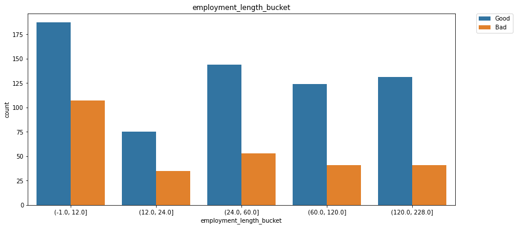

```python
plt.figure(figsize=(13, 6))
ax = sns.countplot(x="employment_length_bucket", hue="risk_flag", data=data)
plt.legend(bbox_to_anchor=(1.05, 1), loc=2, borderaxespad=0.)
plt.title("employment_length_bucket")
plt.show()
```

## Job

```python
# Use function and insert dataframe'data'
display_crosstab_side_by_side(data, 'job', 'risk_flag')
```

| risk_flag job | Bad | Good |
| --- | --- | --- |
| mangement self-employed | 51 | 97 |
| skilled employee | 186 | 444 |
| unemployed non-resident | 7 | 15 |
| unskilled resident | 56 | 144 |

| risk_flag job | Bad | Good |
| --- | --- | --- |
| mangement self-employed | 5 | 10 |
| skilled employee | 19 | 44 |
| unemployed non-resident | 1 | 2 |
| unskilled resident | 6 | 14 |

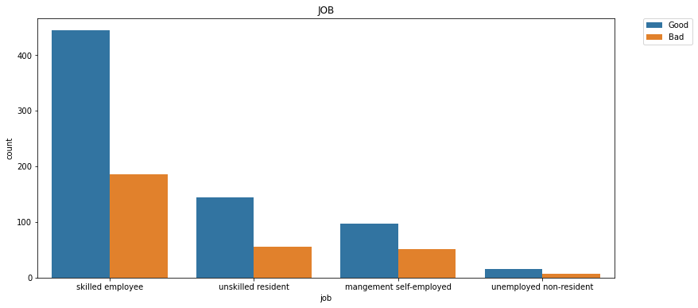

```python
plt.figure(figsize=(13, 6))
ax = sns.countplot(x="job", hue="risk_flag", data=data)
plt.legend(bbox_to_anchor=(1.05, 1), loc=2, borderaxespad=0.)
plt.title("JOB")
plt.show()
```

## Gender

```python
# Use function and insert dataframe'data'
display_crosstab_side_by_side(data, 'gender', 'risk_flag')
```

| risk_flag gender | Bad | Good |
| --- | --- | --- |
| female | 109 | 201 |
| male | 191 | 499 |

| risk_flag gender | Bad | Good |
| --- | --- | --- |
| female | 11 | 20 |
| male | 19 | 50 |

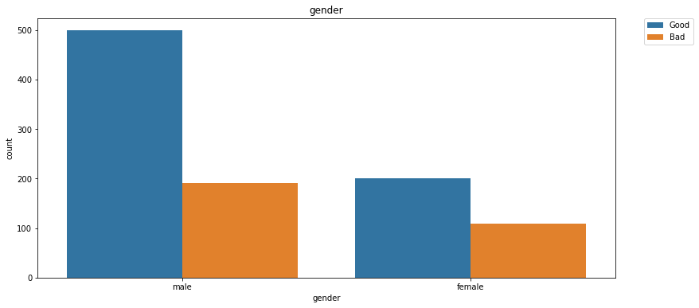

```python
plt.figure(figsize=(13, 6))
ax = sns.countplot(x="gender", hue="risk_flag", data=data)
plt.legend(bbox_to_anchor=(1.05, 1), loc=2, borderaxespad=0.)
plt.title("gender")
plt.show()
```

## Compute WOE AND IV

Top features that appears to have high predictive strength

- 'checking_balance_flag',
- 'credit_history',
- 'months_loan_duration_bucket',
- 'purpose',
- 'property',
- 'checking_balance_bucket',
- 'Amount_bucket',
- 'savings_balance_flag',

```python
data_f=data[[  'credit_history', 'purpose', 'installment_rate',
       'personal_status', 'other_debtors',  'property', 'installment_plan', 'housing', 'existing_credits',
       'dependents', 'foreign_worker', 'job', 'gender',
       'risk_flag', 'checking_balance_flag', 'savings_balance_flag',
        'telephone_flag',
       'Amount_bucket', 'months_loan_duration_bucket',
       'Residence_history_month_bucket', 'employment_length_bucket',
       'checking_balance_bucket']]
```

```python
def convert_to_string_and_fill_missing(df):
    # Convert all columns to string (object)
    df = df.astype(str)

    # Fill missing values with "missing"
    df = df.replace('nan', 'missing', regex=True)

    return df
```

```python
data_f=convert_to_string_and_fill_missing(data_f)
```

```python
data_f.isna().sum()
```

```
credit_history                    0
purpose                           0
installment_rate                  0
personal_status                   0
other_debtors                     0
property                          0
installment_plan                  0
housing                           0
existing_credits                  0
dependents                        0
foreign_worker                    0
job                               0
gender                            0
risk_flag                         0
checking_balance_flag             0
savings_balance_flag              0
telephone_flag                    0
Amount_bucket                     0
months_loan_duration_bucket       0
Residence_history_month_bucket    0
employment_length_bucket          0
checking_balance_bucket           0
dtype: int64
```

```python
data_f.columns
```

```
Index(['credit_history', 'purpose', 'installment_rate', 'personal_status',
       'other_debtors', 'property', 'installment_plan', 'housing',
       'existing_credits', 'dependents', 'foreign_worker', 'job', 'gender',
       'risk_flag', 'checking_balance_flag', 'savings_balance_flag',
       'telephone_flag', 'Amount_bucket', 'months_loan_duration_bucket',
       'Residence_history_month_bucket', 'employment_length_bucket',
       'checking_balance_bucket'],
      dtype='object')
```

```python
data_columns = ['credit_history', 'purpose', 'installment_rate',
                'personal_status', 'other_debtors', 'property', 'installment_plan', 'housing',
                'existing_credits', 'dependents', 'foreign_worker', 'job', 'gender',
                'risk_flag', 'checking_balance_flag', 'savings_balance_flag', 'telephone_flag',
                'Amount_bucket', 'months_loan_duration_bucket', 'Residence_history_month_bucket',
                'employment_length_bucket', 'checking_balance_bucket']

IV_df = pd.DataFrame(columns=['Variable', 'IV'])
for col in data_columns:
    if col == 'risk_flag':  # Skip the target variable
        continue
    else:
        iv = calculate_woe_iv(data, col, 'risk_flag')
        IV_df = IV_df.append({
            "Variable": col,
            "IV": iv,
        }, ignore_index=True)

IV_df_sorted_asc = IV_df.sort_values(by='IV', ascending=False)

IV_df_sorted_asc.head(100)
```

|  | Variable | IV |
| --- | --- | --- |
| 13 | checking_balance_flag | 0.635 |
| 0 | credit_history | 0.293 |
| 17 | months_loan_duration_bucket | 0.216 |
| 1 | purpose | 0.169 |
| 5 | property | 0.113 |
| 20 | checking_balance_bucket | 0.112 |
| 16 | Amount_bucket | 0.093 |
| 14 | savings_balance_flag | 0.091 |
| 7 | housing | 0.083 |
| 19 | employment_length_bucket | 0.060 |
| 6 | installment_plan | 0.058 |
| 3 | personal_status | 0.045 |
| 10 | foreign_worker | 0.044 |
| 4 | other_debtors | 0.032 |
| 12 | gender | 0.027 |
| 2 | installment_rate | 0.026 |
| 18 | Residence_history_month_bucket | 0.015 |
| 8 | existing_credits | 0.013 |
| 11 | job | 0.009 |
| 15 | telephone_flag | 0.006 |
| 9 | dependents | 0.000 |

## Modeling and Evaluation

```python
data_m=data_f.copy()
```

```python
from category_encoders import *
from sklearn.model_selection import train_test_split
from sklearn.metrics import roc_auc_score
from sklearn import preprocessing
from sklearn.metrics import confusion_matrix, classification_report

from xgboost import XGBClassifier
from xgboost import plot_importance

from sklearn.base import BaseEstimator, TransformerMixin
from sklearn.linear_model import LinearRegression
from sklearn.ensemble import RandomForestRegressor
from sklearn.compose import ColumnTransformer
from sklearn.pipeline import Pipeline
from sklearn.impute import SimpleImputer
from sklearn.preprocessing import StandardScaler, OneHotEncoder

import joblib
```

I'm using the category_encoders , compared to the dummy variable encoding. Reason is because they make data smaller, work faster, and handle new categories well. They also encode ordered data and use target information, avoiding issues like overfitting and are easily fitted into data processing pipelines.

https://gsarantitis.wordpress.com/2019/07/16/how-to-persist-categorical-encoding-in-machine-learning-deployment-phase/

```python
categ = ['credit_history', 'purpose', 'installment_rate','personal_status', 'other_debtors',  'property', 'installment_plan', 'housing', 'existing_credits',
       'dependents', 'foreign_worker', 'job', 'gender', 'checking_balance_flag', 'savings_balance_flag',
        'telephone_flag','Amount_bucket', 'months_loan_duration_bucket','Residence_history_month_bucket', 'employment_length_bucket',
        'checking_balance_bucket']

# Encode Categorical Columns
enc = OrdinalEncoder().fit(data_m[categ])
data_m[categ]= enc.transform(data_m[categ])
```

```python
data_m.head(10)
```

|  | credit_history | purpose | installment_rate | personal_status | other_debtors | property | installment_plan | housing | existing_credits | dependents | foreign_worker | job | gender | risk_flag | checking_balance_flag | savings_balance_flag | telephone_flag | Amount_bucket | months_loan_duration_bucket | Residence_history_month_bucket | employment_length_bucket | checking_balance_bucket |
| --- | --- | --- | --- | --- | --- | --- | --- | --- | --- | --- | --- | --- | --- | --- | --- | --- | --- | --- | --- | --- | --- | --- |
| 0 | 1 | 1 | 1 | 1 | 1 | 1 | 1 | 1 | 1 | 1 | 1 | 1 | 1 | Good | 1 | 1 | 1 | 1 | 1 | 1 | 1 | 1 |
| 1 | 2 | 1 | 2 | 2 | 1 | 1 | 1 | 1 | 2 | 1 | 1 | 1 | 2 | Bad | 2 | 2 | 2 | 2 | 2 | 2 | 2 | 2 |
| 2 | 1 | 2 | 2 | 1 | 1 | 1 | 1 | 1 | 2 | 2 | 1 | 2 | 1 | Good | 3 | 2 | 2 | 3 | 1 | 1 | 3 | 3 |
| 3 | 2 | 3 | 2 | 1 | 2 | 2 | 1 | 2 | 2 | 2 | 1 | 1 | 1 | Good | 1 | 2 | 2 | 2 | 2 | 3 | 3 | 1 |
| 4 | 3 | 4 | 3 | 1 | 1 | 3 | 1 | 2 | 1 | 2 | 1 | 1 | 1 | Bad | 1 | 2 | 2 | 2 | 3 | 3 | 3 | 4 |
| 5 | 2 | 2 | 2 | 1 | 1 | 3 | 1 | 2 | 2 | 2 | 1 | 2 | 1 | Good | 3 | 1 | 1 | 2 | 2 | 1 | 2 | 3 |
| 6 | 2 | 3 | 3 | 1 | 1 | 2 | 1 | 1 | 2 | 1 | 1 | 1 | 1 | Good | 3 | 2 | 2 | 3 | 3 | 3 | 1 | 3 |
| 7 | 2 | 5 | 2 | 1 | 1 | 4 | 1 | 3 | 2 | 1 | 1 | 3 | 1 | Good | 2 | 2 | 1 | 2 | 2 | 2 | 2 | 5 |
| 8 | 2 | 1 | 2 | 3 | 1 | 1 | 1 | 1 | 2 | 1 | 1 | 2 | 1 | Good | 3 | 2 | 2 | 4 | 1 | 4 | 3 | 3 |
| 9 | 1 | 4 | 1 | 4 | 1 | 4 | 1 | 1 | 1 | 1 | 1 | 3 | 1 | Bad | 2 | 2 | 2 | 2 | 4 | 5 | 4 | 6 |

```python
X = data_m.drop('risk_flag', axis=1)
y = data_m.risk_flag

X_train, X_test, y_train, y_test = train_test_split(X, y, test_size=0.3, random_state= 42)
```

I selected the Logistic regression and random forest for the choice of my algorithm

Reason

- Logistic regression provides interpretability of coefficients, enabling understanding of feature impact on the target, making it suitable for regulatory compliance and risk assessment.
- Random forest captures complex relationships between features and the target, handles outliers well, and offers feature importance analysis, making it suitable for accurate prediction and risk assessment in credit scoring.

```python
from sklearn.linear_model import LogisticRegression
lr=LogisticRegression(C=0.615848211066026, class_weight=None, dual=False,
                   fit_intercept=True, intercept_scaling=1, l1_ratio=None,
                   max_iter=100, multi_class='auto', n_jobs=None, penalty='l1',
                   random_state=None, solver='liblinear', tol=0.0001, verbose=0,
                   warm_start=False)
lr.fit(X_train, y_train)
lr_pred=lr.predict(X_test)
```

```python
print(confusion_matrix(y_test, lr_pred))
print(classification_report(y_test, lr_pred))
```

```
[[ 29  62]
 [ 15 194]]
              precision    recall  f1-score   support

         Bad       0.66      0.32      0.43        91
        Good       0.76      0.93      0.83       209

    accuracy                           0.74       300
   macro avg       0.71      0.62      0.63       300
weighted avg       0.73      0.74      0.71       300
```

#### Feature Importance for the logistic regression model

```python
# Create a DataFrame to hold feature names and their corresponding coefficients
coefficients_df = pd.DataFrame({'Feature': X_train.columns, 'Coefficient': lr.coef_[0]})

# Sort the DataFrame by coefficient magnitude (absolute value) in descending order
coefficients_df['Absolute Coefficient'] = np.abs(coefficients_df['Coefficient'])
coefficients_df = coefficients_df.sort_values(by='Absolute Coefficient', ascending=False)

# Print the feature importance (coefficients) in descending order
print(coefficients_df[['Feature', 'Coefficient']])
```

```
                           Feature  Coefficient
13           checking_balance_flag        0.861
10                  foreign_worker        0.787
0                   credit_history       -0.376
12                          gender       -0.264
6                 installment_plan       -0.185
14            savings_balance_flag       -0.174
7                          housing       -0.172
5                         property       -0.162
16                   Amount_bucket        0.133
2                 installment_rate        0.124
18  Residence_history_month_bucket        0.072
3                  personal_status       -0.071
17     months_loan_duration_bucket        0.045
1                          purpose       -0.035
19        employment_length_bucket       -0.017
20         checking_balance_bucket       -0.005
4                    other_debtors        0.000
11                             job        0.000
15                  telephone_flag        0.000
9                       dependents        0.000
8                 existing_credits        0.000
Warning: string series 'monitoring/stdout' value was longer than 1000 characters and was truncated. This warning is printed only once per series.
Warning: string series 'monitoring/stdout' value was longer than 1000 characters and was truncated. This warning is printed only once per series.
```

Features with larger absolute coefficients have a stronger impact on the target variable i.e

**Observations:**

The model shows better performance in predicting the "Good" class compared to the "Bad" class, as indicated by higher precision, recall, and F1-score for the "Good" class.

The recall for the "Bad" class is relatively low (32%), which suggests that the model struggles to correctly identify instances of the "Bad" class.

The model has high precision (76%) for the "Good" class, indicating that it is good at correctly predicting "Good" instances among the total positive predictions.

The overall accuracy of the model is 74%, suggesting that it classifies 74% of instances correctly.

The macro-averaged F1-score (63%) considers the balance between the two classes, providing an overall assessment of the model's performance.

The weighted-averaged F1-score (71%) accounts for class imbalances in the dataset, giving higher weight to the larger class (in this case, the "Good" class).

```python
from sklearn.ensemble import RandomForestClassifier
rfc = RandomForestClassifier(max_depth=10, class_weight='balanced', random_state=42)
rfc.fit(X_train, y_train)
rfc_pred = rfc.predict(X_test)
```

```python
print(confusion_matrix(y_test, rfc_pred))
print(classification_report(y_test, rfc_pred))
```

```
[[ 37  54]
 [ 21 188]]
              precision    recall  f1-score   support

         Bad       0.64      0.41      0.50        91
        Good       0.78      0.90      0.83       209

    accuracy                           0.75       300
   macro avg       0.71      0.65      0.67       300
weighted avg       0.73      0.75      0.73       300
```

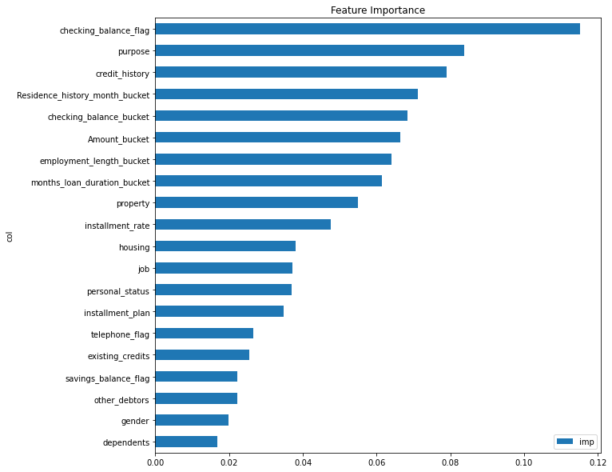

```python
fea_imp = pd.DataFrame({'imp':rfc.feature_importances_, 'col': X.columns})
fea_imp = fea_imp.sort_values(['imp', 'col'], ascending=[True, False]).iloc[-20:]
_ = fea_imp.plot(kind='barh', x='col', y='imp', title='Feature Importance',figsize=(10, 10))
plt.savefig('Random_Forest_Feature_importance.png')
```

Observations for Random Forest results:

- The Random Forest model has a slightly higher accuracy (75%) compared to Logistic Regression (74%).
- Precision for the "Bad" class is 64%, while recall is 41%, indicating the model's ability to correctly identify true "Bad" instances but with a relatively high false positive rate.
- For the "Good" class, precision is 78%, and recall is 90%, indicating a good balance of precision and recall for the "Good" predictions.
- The F1-score for the "Bad" class is 50%, while for the "Good" class, it is 83%, indicating better overall performance in predicting the "Good" class.
- The macro-averaged F1-score for Random Forest is 67%, which is slightly higher than Logistic Regression's macro-averaged F1-score (63%).
- The weighted-averaged F1-score for Random Forest is 73%, showing a good balance of F1-scores for both classes, similar to Logistic Regression (71%).
- Checking balance flag and purpose of the loan appears to be the most important feature in the model

**Conclusion**  
Thought the random forest has higher accuracy, i will choose the logistic regression model because of its interpretability and simplicity and especially in scenarios where understanding the model's decisions is essential

**Recommendations and other fine tuning**  
Given the imbalanced class distribution, further exploration of techniques such as class weighting or sampling strategies may be beneficial to improve the model's performance, especially in predicting the "Bad" class.

## ROC AUC CURVE

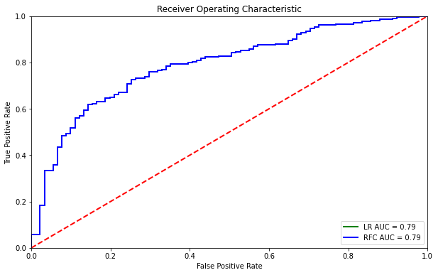

```python
import sklearn.metrics as metrics
import matplotlib.pyplot as plt

probs_1 = lr.predict_proba(X_test)
probs_2 = rfc.predict_proba(X_test)
preds_1 = probs_1[:, 1]
preds_2 = probs_1[:, 1]

fpr_1, tpr_1, threshold_1 = metrics.roc_curve(y_test, preds_1, pos_label='Good')
roc_auc_1 = metrics.auc(fpr_1, tpr_1)

fpr_2, tpr_2, threshold_2 = metrics.roc_curve(y_test, preds_2, pos_label='Good')
roc_auc_2 = metrics.auc(fpr_2, tpr_2)

# Increase figure size and linewidth
plt.figure(figsize=(10, 6))
plt.title('Receiver Operating Characteristic')
plt.plot(fpr_1, tpr_1, 'g', label='LR AUC = %0.2f' % roc_auc_1, linewidth=2)
plt.plot(fpr_2, tpr_2, 'b', label='RFC AUC = %0.2f' % roc_auc_2, linewidth=2)
plt.legend(loc='lower right')
plt.plot([0, 1], [0, 1], 'r--', linewidth=2)
plt.xlim([0, 1])
plt.ylim([0, 1])
plt.ylabel('True Positive Rate')
plt.xlabel('False Positive Rate')
plt.show()
```

An AUC (Area Under the Curve) value of 79% indicates that our model's performance in distinguishing between the good and bad classes is reasonably good